# Kecamatan Dalam Angka (KCDA) Kabupaten Tasikmalaya Tahun 2022

Diberikan dataset dalam bentuk xlsx. Isi dari data ini nantinya akan dimasukan kedalam template publikasi buku yang terdiri dari tabel beserta beberapa visualisasi dalam bentuk grafik.

#### Load Dataset

```python
import pandas as pd
```

```python
df1 = pd.read_excel('D:/Test/kcda.xlsx', sheet_name  = "sarana_kesehatan")
df2 = pd.read_excel('D:/Test/kcda.xlsx', sheet_name  = "jumlah_sls")
df3 = pd.read_excel('D:/Test/kcda.xlsx', sheet_name  = "wabah_penyakit")
df4 = pd.read_excel('D:/Test/kcda.xlsx', sheet_name  = "wabah_meninggal")
df5 = pd.read_excel('D:/Test/kcda.xlsx', sheet_name  = "tempat_ibadah")
df6 = pd.read_excel('D:/Test/kcda.xlsx', sheet_name  = "lembaga_kemasyarakatan")
df7 = pd.read_excel('D:/Test/kcda.xlsx', sheet_name  = "bts")
df8 = pd.read_excel('D:/Test/kcda.xlsx', sheet_name  = "sinyal")
df9 = pd.read_excel('D:/Test/kcda.xlsx', sheet_name  = "pos")
df10 = pd.read_excel('D:/Test/kcda.xlsx', sheet_name  = "industri")
df11 = pd.read_excel('D:/Test/kcda.xlsx', sheet_name  = "perbankan")
df12 = pd.read_excel('D:/Test/kcda.xlsx', sheet_name  = "kud")
df13 = pd.read_excel('D:/Test/kcda.xlsx', sheet_name  = "sarana_prasarana")
df14 = pd.read_excel('D:/Test/kcda.xlsx', sheet_name  = "linmas")
df15 = pd.read_excel('D:/Test/kcda.xlsx', sheet_name  = "bumdes")
```

#### 1. Mengenal Dataset

File "kcda.xlsx." ini terdiri dari 15 worksheet, berikut adalah rincian isi dari masing-masing worksheet :

##### Sheet 1 = sarana_kesehatan

```python
df1.head()
```

|  | Kecamatan | Rumah Sakit | Rumah Sakit Bersalin | Puskesmas Dengan Rawat Inap | Puskesmas Tanpa Rawat Inap | Pustu | Poliklinik/ Balai Pengobatan | Praktik Dokter | Rumah Bersalin | Praktik Bidan | Poskesdes | Polindes | Apotek | Toko Khusus Obat/Jamu |
| --- | --- | --- | --- | --- | --- | --- | --- | --- | --- | --- | --- | --- | --- | --- |
| 0 | 010 | 0 | 0 | 1 | 0 | 8 | 3 | 2 | 0 | 17 | 1 | 8 | 6 | 2 |
| 1 | Cipatujah | 0 | 0 | 1 | 0 | 8 | 3 | 2 | 0 | 17 | 1 | 8 | 6 | 2 |
| 2 | Bantarkalong | 0 | 0 | 0 | 0 | 0 | 0 | 0 | 0 | 3 | 0 | 0 | 0 | 0 |
| 3 | Ciandum | 0 | 0 | 0 | 0 | 0 | 0 | 0 | 0 | 1 | 0 | 1 | 0 | 0 |
| 4 | Ciheras | 0 | 0 | 0 | 0 | 1 | 1 | 0 | 0 | 1 | 0 | 1 | 2 | 1 |

```python
df1.info()
print(df1.columns)
print(df1.shape)
```

```
<class 'pandas.core.frame.DataFrame'>
RangeIndex: 430 entries, 0 to 429
Data columns (total 14 columns):
 #   Column                        Non-Null Count  Dtype
---  ------                        --------------  -----
 0   Kecamatan                     430 non-null    object
 1   Rumah Sakit                   430 non-null    int64
 2   Rumah Sakit Bersalin          430 non-null    int64
 3   Puskesmas Dengan Rawat Inap   430 non-null    int64
 4   Puskesmas Tanpa Rawat Inap    430 non-null    int64
 5   Pustu                         430 non-null    int64
 6   Poliklinik/ Balai Pengobatan  430 non-null    int64
 7   Praktik Dokter                430 non-null    int64
 8   Rumah Bersalin                430 non-null    int64
 9   Praktik Bidan                 430 non-null    int64
 10  Poskesdes                     430 non-null    int64
 11  Polindes                      430 non-null    int64
 12  Apotek                        430 non-null    int64
 13  Toko Khusus Obat/Jamu         430 non-null    int64
dtypes: int64(13), object(1)
memory usage: 47.2+ KB
Index(['Kecamatan', 'Rumah Sakit', 'Rumah Sakit Bersalin',
       'Puskesmas Dengan Rawat Inap', 'Puskesmas Tanpa Rawat Inap', 'Pustu',
       'Poliklinik/ Balai Pengobatan', 'Praktik Dokter', 'Rumah Bersalin',
       'Praktik Bidan', 'Poskesdes', 'Polindes', 'Apotek',
       'Toko Khusus Obat/Jamu'],
      dtype='object')
(430, 14)
```

###### Description

Dataset pertama yaitu sarana_kesehatan yang terdiri dari 430 baris dan 14 kolom. Berisi tentang masing masing jumlah sarana kesehatan di setiap kecamatan yang ada di Kabupaten Tasikmalaya

##### Sheet 2 = jumlah_sls

```python
df2.head()
```

|  | Kecamatan | Jumlah SLS Terkecil | Unnamed: 2 | Unnamed: 3 | Unnamed: 4 | Unnamed: 5 |
| --- | --- | --- | --- | --- | --- | --- |
| 0 | 010 | 418 | NaN | NaN | NaN | NaN |
| 1 | Cipatujah | 418 | NaN | NaN | NaN | NaN |
| 2 | Bantarkalong | 25 | NaN | NaN | NaN | NaN |
| 3 | Ciandum | 35 | NaN | NaN | NaN | NaN |
| 4 | Ciheras | 42 | NaN | NaN | NaN | NaN |

```python
df2.info()
print(df2.columns)
print(df2.shape)
```

```
<class 'pandas.core.frame.DataFrame'>
RangeIndex: 430 entries, 0 to 429
Data columns (total 6 columns):
 #   Column               Non-Null Count  Dtype
---  ------               --------------  -----
 0   Kecamatan            430 non-null    object
 1   Jumlah SLS Terkecil  430 non-null    int64
 2   Unnamed: 2           0 non-null      float64
 3   Unnamed: 3           0 non-null      float64
 4   Unnamed: 4           1 non-null      object
 5   Unnamed: 5           1 non-null      object
dtypes: float64(2), int64(1), object(3)
memory usage: 20.3+ KB
Index(['Kecamatan', 'Jumlah SLS Terkecil', 'Unnamed: 2', 'Unnamed: 3',
       'Unnamed: 4', 'Unnamed: 5'],
      dtype='object')
(430, 6)
```

###### Description

Dataset kedua yaitu jumlah_sls yang terdiri dari 430 baris dan 6 kolom. Berisi tentang masing masing jumlah satuan lingkungan setempat di setiap kecamatan yang ada di Kabupaten Tasikmalaya.

##### Sheet 3 = wabah_penyakit

```python
df3.head()
```

|  | Kecamatan | Muntaber/Diare | Demam Berdarah | Campak | Malaria | Flu Burung/ SARS | Hepatitis E | Difteri | Corona/ COVID-19 | Kerawanan Pangan | Lainnya |
| --- | --- | --- | --- | --- | --- | --- | --- | --- | --- | --- | --- |
| 0 | 010 | 0 | 0 | 0 | 2 | 0 | 1 | 0 | 94 | 0 | 0 |
| 1 | Cipatujah | 0 | 0 | 0 | 2 | 0 | 1 | 0 | 94 | 0 | 0 |
| 2 | Bantarkalong | 0 | 0 | 0 | 0 | 0 | 0 | 0 | 1 | 0 | 0 |
| 3 | Ciandum | 0 | 0 | 0 | 0 | 0 | 0 | 0 | 0 | 0 | 0 |
| 4 | Ciheras | 0 | 0 | 0 | 0 | 0 | 0 | 0 | 2 | 0 | 0 |

```python
df3.info()
print(df3.columns)
print(df3.shape)
```

```
<class 'pandas.core.frame.DataFrame'>
RangeIndex: 430 entries, 0 to 429
Data columns (total 11 columns):
 #   Column            Non-Null Count  Dtype
---  ------            --------------  -----
 0   Kecamatan         430 non-null    object
 1   Muntaber/Diare    430 non-null    int64
 2   Demam Berdarah    430 non-null    int64
 3   Campak            430 non-null    int64
 4   Malaria           430 non-null    int64
 5   Flu Burung/ SARS  430 non-null    int64
 6   Hepatitis E       430 non-null    int64
 7   Difteri           430 non-null    int64
 8   Corona/ COVID-19  430 non-null    int64
 9   Kerawanan Pangan  430 non-null    int64
 10  Lainnya           430 non-null    int64
dtypes: int64(10), object(1)
memory usage: 37.1+ KB
Index(['Kecamatan', 'Muntaber/Diare', 'Demam Berdarah', 'Campak', 'Malaria',
       'Flu Burung/ SARS', 'Hepatitis E', 'Difteri', 'Corona/ COVID-19',
       'Kerawanan Pangan', 'Lainnya'],
      dtype='object')
(430, 11)
```

###### Description

Dataset ketiga yaitu wabah_penyakit yang terdiri dari 430 baris dan 11 kolom. Berisi tentang masing masing jumlah warga yang terdampak wabah penyakit di setiap kecamatan yang ada di Kabupaten Tasikmalaya.

##### Sheet 4 = wabah_meninggal

```python
df4.head()
```

|  | Kecamatan | Muntaber/Diare | Demam Berdarah | Campak | Malaria | Flu Burung/ SARS | Hepatitis E | Difteri | Corona/ COVID-19 | Kerawanan Pangan | Lainnya |
| --- | --- | --- | --- | --- | --- | --- | --- | --- | --- | --- | --- |
| 0 | 010 | 0 | 0.0 | 0.0 | 0.0 | 0.0 | 0.0 | 0.0 | 0.0 | 0.0 | 0.0 |
| 1 | Cipatujah | 0 | 0.0 | 0.0 | 0.0 | 0.0 | 0.0 | 0.0 | 0.0 | 0.0 | 0.0 |
| 2 | Bantarkalong | 0 | 0.0 | 0.0 | 0.0 | 0.0 | 0.0 | 0.0 | 0.0 | 0.0 | 0.0 |
| 3 | Ciandum | 0 | 0.0 | 0.0 | 0.0 | 0.0 | 0.0 | 0.0 | 0.0 | 0.0 | 0.0 |
| 4 | Ciheras | 0 | 0.0 | 0.0 | 0.0 | 0.0 | 0.0 | 0.0 | 0.0 | 0.0 | 0.0 |

```python
df4.info()
print(df4.columns)
print(df4.shape)
```

```
<class 'pandas.core.frame.DataFrame'>
RangeIndex: 431 entries, 0 to 430
Data columns (total 11 columns):
 #   Column            Non-Null Count  Dtype
---  ------            --------------  -----
 0   Kecamatan         431 non-null    object
 1   Muntaber/Diare    430 non-null    object
 2   Demam Berdarah    430 non-null    float64
 3   Campak            430 non-null    float64
 4   Malaria           430 non-null    float64
 5   Flu Burung/ SARS  430 non-null    float64
 6   Hepatitis E       430 non-null    float64
 7   Difteri           430 non-null    float64
 8   Corona/ COVID-19  430 non-null    float64
 9   Kerawanan Pangan  429 non-null    float64
 10  Lainnya           430 non-null    float64
dtypes: float64(9), object(2)
memory usage: 37.2+ KB
Index(['Kecamatan', 'Muntaber/Diare', 'Demam Berdarah', 'Campak', 'Malaria',
       'Flu Burung/ SARS', 'Hepatitis E', 'Difteri', 'Corona/ COVID-19',
       'Kerawanan Pangan', 'Lainnya'],
      dtype='object')
(431, 11)
```

###### Description

Dataset keempat yaitu wabah_meninggal yang terdiri dari 431 baris dan 11 kolom. Berisi tentang masing masing jumlah warga yang meninggal akibat wabah penyakit di setiap kecamatan yang ada di Kabupaten Tasikmalaya.

##### Sheet 5 = tempat_ibadah

```python
df5.head()
```

|  | Kecamatan | Masjid | Surau/ Langgar/ Mushola | Gereja Kristen | Gereja Katolik | Kapel | Pura | Wihara | Kelenteng | Balai Basarah | Lainnya |
| --- | --- | --- | --- | --- | --- | --- | --- | --- | --- | --- | --- |
| 0 | 010 | 173 | 393 | 2 | 0 | 0 | 0 | 0 | 0 | 0 | 0 |
| 1 | Cipatujah | 173 | 393 | 2 | 0 | 0 | 0 | 0 | 0 | 0 | 0 |
| 2 | Bantarkalong | 8 | 25 | 0 | 0 | 0 | 0 | 0 | 0 | 0 | 0 |
| 3 | Ciandum | 16 | 35 | 0 | 0 | 0 | 0 | 0 | 0 | 0 | 0 |
| 4 | Ciheras | 10 | 32 | 0 | 0 | 0 | 0 | 0 | 0 | 0 | 0 |

```python
df5.info()
print(df5.columns)
print(df5.shape)
```

```
<class 'pandas.core.frame.DataFrame'>
RangeIndex: 430 entries, 0 to 429
Data columns (total 11 columns):
 #   Column                   Non-Null Count  Dtype
---  ------                   --------------  -----
 0   Kecamatan                430 non-null    object
 1   Masjid                   430 non-null    int64
 2   Surau/ Langgar/ Mushola  430 non-null    int64
 3   Gereja Kristen           430 non-null    int64
 4   Gereja Katolik           430 non-null    int64
 5   Kapel                    430 non-null    int64
 6   Pura                     430 non-null    int64
 7   Wihara                   430 non-null    int64
 8   Kelenteng                430 non-null    int64
 9   Balai Basarah            430 non-null    int64
 10  Lainnya                  430 non-null    int64
dtypes: int64(10), object(1)
memory usage: 37.1+ KB
Index(['Kecamatan', 'Masjid', 'Surau/ Langgar/ Mushola', 'Gereja Kristen',
       'Gereja Katolik', 'Kapel', 'Pura', 'Wihara', 'Kelenteng',
       'Balai Basarah', 'Lainnya'],
      dtype='object')
(430, 11)
```

##### Sheet 6 = lembaga_kemasyarakatan

```python
df6.head()
```

|  | Kecamatan | PKK | Karang Taruna | Lembaga Adat | Kelompok Tani | Lembaga Pengelolaan Air | Kelompok Masyarakat (Pokmas) |
| --- | --- | --- | --- | --- | --- | --- | --- |
| 0 | 010 | 18 | 35 | 2 | 82 | 7 | 5 |
| 1 | Cipatujah | 18 | 35 | 2 | 82 | 7 | 5 |
| 2 | Bantarkalong | 4 | 1 | 1 | 8 | 1 | 0 |
| 3 | Ciandum | 1 | 1 | 0 | 9 | 0 | 0 |
| 4 | Ciheras | 1 | 8 | 0 | 6 | 1 | 1 |

```python
df6.info()
print(df6.columns)
print(df6.shape)
```

```
<class 'pandas.core.frame.DataFrame'>
RangeIndex: 430 entries, 0 to 429
Data columns (total 7 columns):
 #   Column                        Non-Null Count  Dtype
---  ------                        --------------  -----
 0   Kecamatan                     430 non-null    object
 1   PKK                           430 non-null    int64
 2   Karang Taruna                 430 non-null    int64
 3   Lembaga Adat                  430 non-null    int64
 4   Kelompok Tani                 430 non-null    int64
 5   Lembaga Pengelolaan Air       430 non-null    int64
 6   Kelompok Masyarakat (Pokmas)  430 non-null    int64
dtypes: int64(6), object(1)
memory usage: 23.6+ KB
Index(['Kecamatan', 'PKK', 'Karang Taruna', 'Lembaga Adat', 'Kelompok Tani',
       'Lembaga Pengelolaan Air', 'Kelompok Masyarakat (Pokmas)'],
      dtype='object')
(430, 7)
```

##### Sheet 7 = bts

```python
df7.head()
```

|  | nama_kecamatan | nama_desa | BTS | Operator Layanan seluler |
| --- | --- | --- | --- | --- |
| 0 | CIPATUJAH | CIHERAS | 2 | 3.0 |
| 1 | CIPATUJAH | CIPANAS | 1 | 4.0 |
| 2 | CIPATUJAH | CIANDUM | 1 | 4.0 |
| 3 | CIPATUJAH | CIPATUJAH | 3 | 3.0 |
| 4 | CIPATUJAH | SINDANGKERTA | 3 | 3.0 |

```python
df7.info()
print(df7.columns)
print(df7.shape)
```

```
<class 'pandas.core.frame.DataFrame'>
RangeIndex: 352 entries, 0 to 351
Data columns (total 4 columns):
 #   Column                    Non-Null Count  Dtype
---  ------                    --------------  -----
 0   nama_kecamatan            351 non-null    object
 1   nama_desa                 351 non-null    object
 2   BTS                       352 non-null    int64
 3   Operator Layanan seluler  351 non-null    float64
dtypes: float64(1), int64(1), object(2)
memory usage: 11.1+ KB
Index(['nama_kecamatan', 'nama_desa', 'BTS', 'Operator Layanan seluler'], dtype='object')
(352, 4)
```

###### Description

Dataset ketujuh yaitu bts yang terdiri dari 352 baris dan 4 kolom. Berisi tentang masing masing Base Transceiver Station (BTS) di setiap kecamatan yang ada di Kabupaten Tasikmalaya.

##### Sheet 8 = sinyal

```python
df8.head()
```

|  | nama_kecamatan | nama_desa | Sinyal_telepon | Sinyal_internet |
| --- | --- | --- | --- | --- |
| 0 | CIPATUJAH | CIHERAS | Sinyal Sangat Kuat | 4G/LTE |
| 1 | CIPATUJAH | CIPANAS | Sinyal Kuat | 4G/LTE |
| 2 | CIPATUJAH | CIANDUM | Sinyal Kuat | 4G/LTE |
| 3 | CIPATUJAH | CIPATUJAH | Sinyal Kuat | 4G/LTE |
| 4 | CIPATUJAH | SINDANGKERTA | Sinyal Kuat | 4G/LTE |

```python
df8.info()
print(df8.columns)
print(df8.shape)
```

```
<class 'pandas.core.frame.DataFrame'>
RangeIndex: 351 entries, 0 to 350
Data columns (total 4 columns):
 #   Column           Non-Null Count  Dtype
---  ------           --------------  -----
 0   nama_kecamatan   351 non-null    object
 1   nama_desa        351 non-null    object
 2   Sinyal_telepon   351 non-null    object
 3   Sinyal_internet  351 non-null    object
dtypes: object(4)
memory usage: 11.1+ KB
Index(['nama_kecamatan', 'nama_desa', 'Sinyal_telepon', 'Sinyal_internet'], dtype='object')
(351, 4)
```

##### Sheet 9 = pos

```python
df9.head()
```

|  | nama_kecamatan | nama_desa | Pos | Pos_Keliling | Ekspedisi |
| --- | --- | --- | --- | --- | --- |
| 0 | CIPATUJAH | CIHERAS | Tidak Ada | Tidak Ada | Tidak Ada |
| 1 | CIPATUJAH | CIPANAS | Tidak Ada | Ada | Tidak Ada |
| 2 | CIPATUJAH | CIANDUM | Tidak Ada | Tidak Ada | Tidak Ada |
| 3 | CIPATUJAH | CIPATUJAH | Beroperasi | Ada | Beroperasi |
| 4 | CIPATUJAH | SINDANGKERTA | Tidak Ada | Ada | Tidak Ada |

```python
df9.info()
print(df9.columns)
print(df9.shape)
```

```
<class 'pandas.core.frame.DataFrame'>
RangeIndex: 351 entries, 0 to 350
Data columns (total 5 columns):
 #   Column          Non-Null Count  Dtype
---  ------          --------------  -----
 0   nama_kecamatan  351 non-null    object
 1   nama_desa       351 non-null    object
 2   Pos             351 non-null    object
 3   Pos_Keliling    351 non-null    object
 4   Ekspedisi       351 non-null    object
dtypes: object(5)
memory usage: 13.8+ KB
Index(['nama_kecamatan', 'nama_desa', 'Pos', 'Pos_Keliling', 'Ekspedisi'], dtype='object')
(351, 5)
```

###### Description

Dataset kesembilan yaitu pos yang terdiri dari 351 baris dan 5 kolom. Berisi tentang masing masing jumlah jenis pos di setiap kecamatan yang ada di Kabupaten Tasikmalaya.

##### Sheet 10 = industri

```python
df10.head()
```

|  | nama_kecamatan | nama_desa | Kulit | Furnitur | Barang_Logan | Tekstil | Pak_Jadi | Galian_NonLogam | Kayu | Makanan | Minuman | Olah_Tembakau | Kertas | Percetakan | Alat_Angkut | Kerajinan | Reparasi | Lainnya |
| --- | --- | --- | --- | --- | --- | --- | --- | --- | --- | --- | --- | --- | --- | --- | --- | --- | --- | --- |
| 0 | CIPATUJAH | CIHERAS | 0 | 3 | 1 | 0 | 1 | 0 | 1 | 14 | 2 | 0 | 0 | 0 | 0 | 1 | 0 | 2 |
| 1 | CIPATUJAH | CIPANAS | 0 | 2 | 0 | 0 | 0 | 0 | 0 | 1 | 0 | 0 | 0 | 0 | 0 | 0 | 1 | 0 |
| 2 | CIPATUJAH | CIANDUM | 0 | 0 | 0 | 0 | 5 | 0 | 0 | 24 | 24 | 0 | 0 | 0 | 0 | 0 | 5 | 0 |
| 3 | CIPATUJAH | CIPATUJAH | 0 | 3 | 0 | 0 | 3 | 5 | 5 | 20 | 20 | 0 | 0 | 0 | 0 | 0 | 1 | 0 |
| 4 | CIPATUJAH | SINDANGKERTA | 0 | 6 | 0 | 0 | 3 | 12 | 0 | 66 | 66 | 0 | 0 | 0 | 0 | 2 | 0 | 0 |

```python
df10.info()
print(df10.columns)
print(df10.shape)
```

```
<class 'pandas.core.frame.DataFrame'>
RangeIndex: 351 entries, 0 to 350
Data columns (total 18 columns):
 #   Column           Non-Null Count  Dtype
---  ------           --------------  -----
 0   nama_kecamatan   351 non-null    object
 1   nama_desa        351 non-null    object
 2   Kulit            351 non-null    int64
 3   Furnitur         351 non-null    int64
 4   Barang_Logan     351 non-null    int64
 5   Tekstil          351 non-null    int64
 6   Pak_Jadi         351 non-null    int64
 7   Galian_NonLogam  351 non-null    int64
 8   Kayu             351 non-null    int64
 9   Makanan          351 non-null    int64
 10  Minuman          351 non-null    int64
 11  Olah_Tembakau    351 non-null    int64
 12  Kertas           351 non-null    int64
 13  Percetakan       351 non-null    int64
 14  Alat_Angkut      351 non-null    int64
 15  Kerajinan        351 non-null    int64
 16  Reparasi         351 non-null    int64
 17  Lainnya          351 non-null    int64
dtypes: int64(16), object(2)
memory usage: 49.5+ KB
Index(['nama_kecamatan', 'nama_desa', 'Kulit', 'Furnitur', 'Barang_Logan',
       'Tekstil', 'Pak_Jadi', 'Galian_NonLogam', 'Kayu', 'Makanan', 'Minuman',
       'Olah_Tembakau', 'Kertas', 'Percetakan', 'Alat_Angkut', 'Kerajinan',
       'Reparasi', 'Lainnya'],
      dtype='object')
(351, 18)
```

###### Description

Dataset kesepuluh yaitu industri yang terdiri dari 351 baris dan 18 kolom. Berisi tentang jumlah masing masing jenis industri di setiap kecamatan yang ada di Kabupaten Tasikmalaya.

##### Sheet 11 = perbankan

```python
df11.head()
```

|  | nama_kecamatan | nama_desa | Bank_Pemerintah | Bank_Swasta | BPR |
| --- | --- | --- | --- | --- | --- |
| 0 | CIPATUJAH | CIHERAS | 0 | 0 | 0 |
| 1 | CIPATUJAH | CIPANAS | 0 | 0 | 0 |
| 2 | CIPATUJAH | CIANDUM | 0 | 0 | 0 |
| 3 | CIPATUJAH | CIPATUJAH | 1 | 1 | 1 |
| 4 | CIPATUJAH | SINDANGKERTA | 0 | 0 | 0 |

```python
df11.info()
print(df11.columns)
print(df11.shape)
```

```
<class 'pandas.core.frame.DataFrame'>
RangeIndex: 351 entries, 0 to 350
Data columns (total 5 columns):
 #   Column           Non-Null Count  Dtype
---  ------           --------------  -----
 0   nama_kecamatan   351 non-null    object
 1   nama_desa        351 non-null    object
 2   Bank_Pemerintah  351 non-null    int64
 3   Bank_Swasta      351 non-null    int64
 4   BPR              351 non-null    int64
dtypes: int64(3), object(2)
memory usage: 13.8+ KB
Index(['nama_kecamatan', 'nama_desa', 'Bank_Pemerintah', 'Bank_Swasta', 'BPR'], dtype='object')
(351, 5)
```

###### Description

Dataset kesebelas yaitu perbankan yang terdiri dari 351 baris dan 5 kolom. Berisi tentang jumlah masing masing dari jenis perbankan di setiap kecamatan yang ada di Kabupaten Tasikmalaya.

##### Sheet 12 = kud

```python
df12.head()
```

|  | nama_kecamatan | nama_desa | KUD | Ind_Kecil | Kospin | Lainnya |
| --- | --- | --- | --- | --- | --- | --- |
| 0 | CIPATUJAH | CIHERAS | 0 | 0 | 0 | 0 |
| 1 | CIPATUJAH | CIPANAS | 0 | 0 | 0 | 0 |
| 2 | CIPATUJAH | CIANDUM | 0 | 0 | 0 | 0 |
| 3 | CIPATUJAH | CIPATUJAH | 0 | 0 | 0 | 0 |
| 4 | CIPATUJAH | SINDANGKERTA | 0 | 0 | 0 | 0 |

```python
df12.info()
print(df12.columns)
print(df12.shape)
```

```
<class 'pandas.core.frame.DataFrame'>
RangeIndex: 352 entries, 0 to 351
Data columns (total 6 columns):
 #   Column          Non-Null Count  Dtype
---  ------          --------------  -----
 0   nama_kecamatan  351 non-null    object
 1   nama_desa       351 non-null    object
 2   KUD             352 non-null    int64
 3   Ind_Kecil       352 non-null    int64
 4   Kospin          352 non-null    int64
 5   Lainnya         352 non-null    int64
dtypes: int64(4), object(2)
memory usage: 16.6+ KB
Index(['nama_kecamatan', 'nama_desa', 'KUD', 'Ind_Kecil', 'Kospin', 'Lainnya'], dtype='object')
(352, 6)
```

###### Description

Dataset keduabelas yaitu kud yang terdiri dari 352 baris dan 6 kolom. Berisi tentang jumlah masing masing dari jenis Koperasi Unit Desa (KUD) di setiap kecamatan yang ada di Kabupaten Tasikmalaya.

##### Sheet 13 = sarana_prasarana

```python
df13.head()
```

|  | nama_kecamatan | nama_desa | Pertokoan | Pasar_permanen | Semi_Permanen | Non_Bangunan | Minimarket | Resto/RM | WR_Makan | Hotel | Penginapan | TK_Kelontong |
| --- | --- | --- | --- | --- | --- | --- | --- | --- | --- | --- | --- | --- |
| 0 | CIPATUJAH | CIHERAS | 1 | 1 | 0 | 0 | 0 | 2 | 17 | 0 | 0 | 117 |
| 1 | CIPATUJAH | CIPANAS | 0 | 0 | 0 | 0 | 0 | 0 | 2 | 0 | 0 | 36 |
| 2 | CIPATUJAH | CIANDUM | 0 | 0 | 0 | 0 | 0 | 0 | 10 | 0 | 0 | 64 |
| 3 | CIPATUJAH | CIPATUJAH | 0 | 0 | 1 | 0 | 2 | 0 | 40 | 0 | 3 | 130 |
| 4 | CIPATUJAH | SINDANGKERTA | 0 | 0 | 1 | 0 | 1 | 0 | 45 | 0 | 7 | 122 |

```python
df13.info()
print(df13.columns)
print(df13.shape)
```

```
<class 'pandas.core.frame.DataFrame'>
RangeIndex: 351 entries, 0 to 350
Data columns (total 12 columns):
 #   Column          Non-Null Count  Dtype
---  ------          --------------  -----
 0   nama_kecamatan  351 non-null    object
 1   nama_desa       351 non-null    object
 2   Pertokoan       351 non-null    int64
 3   Pasar_permanen  351 non-null    int64
 4   Semi_Permanen   351 non-null    int64
 5   Non_Bangunan    351 non-null    int64
 6   Minimarket      351 non-null    int64
 7   Resto/RM        351 non-null    int64
 8   WR_Makan        351 non-null    int64
 9   Hotel           351 non-null    int64
 10  Penginapan      351 non-null    int64
 11  TK_Kelontong    351 non-null    int64
dtypes: int64(10), object(2)
memory usage: 33.0+ KB
Index(['nama_kecamatan', 'nama_desa', 'Pertokoan', 'Pasar_permanen',
       'Semi_Permanen', 'Non_Bangunan', 'Minimarket', 'Resto/RM', 'WR_Makan',
       'Hotel', 'Penginapan', 'TK_Kelontong'],
      dtype='object')
(351, 12)
```

###### Description

Dataset ketigabelas yaitu sarana_prasarana yang terdiri dari 351 baris dan 12 kolom. Berisi tentang jumlah masing masing dari sarana prasarana di setiap kecamatan yang ada di Kabupaten Tasikmalaya.

##### Sheet 14 = linmas

```python
df14.head()
```

|  | nama_kecamatan | nama_desa | Linmas |
| --- | --- | --- | --- |
| 0 | CIPATUJAH | CIHERAS | 24 |
| 1 | CIPATUJAH | CIPANAS | 22 |
| 2 | CIPATUJAH | CIANDUM | 25 |
| 3 | CIPATUJAH | CIPATUJAH | 20 |
| 4 | CIPATUJAH | SINDANGKERTA | 20 |

```python
df14.info()
print(df14.columns)
print(df14.shape)
```

```
<class 'pandas.core.frame.DataFrame'>
RangeIndex: 352 entries, 0 to 351
Data columns (total 3 columns):
 #   Column          Non-Null Count  Dtype
---  ------          --------------  -----
 0   nama_kecamatan  351 non-null    object
 1   nama_desa       351 non-null    object
 2   Linmas          352 non-null    int64
dtypes: int64(1), object(2)
memory usage: 8.4+ KB
Index(['nama_kecamatan', 'nama_desa', 'Linmas'], dtype='object')
(352, 3)
```

###### Description

Dataset ke-empatbelas yaitu linmas yang terdiri dari 352 baris dan 3 kolom. Berisi tentang jumlah Perlindungan Masyarakat (LinMas) di setiap kecamatan yang ada di Kabupaten Tasikmalaya.

##### Sheet 15 = bumdes

```python
df15.head()
```

|  | nama_kecamatan | nama_desa | BumDes |
| --- | --- | --- | --- |
| 0 | CIPATUJAH | CIHERAS | 1 |
| 1 | CIPATUJAH | CIPANAS | 1 |
| 2 | CIPATUJAH | CIANDUM | 1 |
| 3 | CIPATUJAH | CIPATUJAH | 1 |
| 4 | CIPATUJAH | SINDANGKERTA | 1 |

```python
df15.info()
print(df15.columns)
print(df15.shape)
```

```
<class 'pandas.core.frame.DataFrame'>
RangeIndex: 351 entries, 0 to 350
Data columns (total 3 columns):
 #   Column          Non-Null Count  Dtype
---  ------          --------------  -----
 0   nama_kecamatan  351 non-null    object
 1   nama_desa       351 non-null    object
 2   BumDes          351 non-null    int64
dtypes: int64(1), object(2)
memory usage: 8.4+ KB
Index(['nama_kecamatan', 'nama_desa', 'BumDes'], dtype='object')
(351, 3)
```

###### Description

Dataset ke-limabelas yaitu BumDes yang terdiri dari 351 baris dan 3 kolom. Berisi tentang jumlah Badan Usaha Milik Desa (BumDes) di setiap kecamatan yang ada di Kabupaten Tasikmalaya.

#### 2. Identifikasi Masalah

##### 2.1 Masalah 1 : Format tabel berbeda

###### 2.1.1 Cek jumlah baris dan kolom tiap dataset

```python
for i in range(1, 16):
    df = globals()[f'df{i}']
    print(f"data{i}_shape :", df.shape)
```

```
data1_shape : (430, 14)
data2_shape : (430, 6)
data3_shape : (430, 11)
data4_shape : (431, 11)
data5_shape : (430, 11)
data6_shape : (430, 7)
data7_shape : (352, 4)
data8_shape : (351, 4)
data9_shape : (351, 5)
data10_shape : (351, 18)
data11_shape : (351, 5)
data12_shape : (352, 6)
data13_shape : (351, 12)
data14_shape : (352, 3)
data15_shape : (351, 3)
```

Terdapat cenderung kesamaan dari data 1 - 6 yaitu terdapat kurang lebih 430 baris dan data 7 -15 yaitu terdapat kurang lebih 351 baris.

```python
for i in range(1, 16):
    df = globals()[f'df{i}']
    print(f"data{i}_columns :", df.columns.tolist())
```

```
data1_columns : ['Kecamatan', 'Rumah Sakit', 'Rumah Sakit Bersalin', 'Puskesmas Dengan Rawat Inap', 'Puskesmas Tanpa Rawat Inap', 'Pustu', 'Poliklinik/ Balai Pengobatan', 'Praktik Dokter', 'Rumah Bersalin', 'Praktik Bidan', 'Poskesdes', 'Polindes', 'Apotek', 'Toko Khusus Obat/Jamu']
data2_columns : ['Kecamatan', 'Jumlah SLS Terkecil', 'Unnamed: 2', 'Unnamed: 3', 'Unnamed: 4', 'Unnamed: 5']
data3_columns : ['Kecamatan', 'Muntaber/Diare', 'Demam Berdarah', 'Campak', 'Malaria', 'Flu Burung/ SARS', 'Hepatitis E', 'Difteri', 'Corona/ COVID-19', 'Kerawanan Pangan', 'Lainnya']
data4_columns : ['Kecamatan', 'Muntaber/Diare', 'Demam Berdarah', 'Campak', 'Malaria', 'Flu Burung/ SARS', 'Hepatitis E', 'Difteri', 'Corona/ COVID-19', 'Kerawanan Pangan', 'Lainnya']
data5_columns : ['Kecamatan', 'Masjid', 'Surau/ Langgar/ Mushola', 'Gereja Kristen', 'Gereja Katolik', 'Kapel', 'Pura', 'Wihara', 'Kelenteng', 'Balai Basarah', 'Lainnya']
data6_columns : ['Kecamatan', 'PKK', 'Karang Taruna', 'Lembaga Adat', 'Kelompok Tani', 'Lembaga Pengelolaan Air', 'Kelompok Masyarakat (Pokmas)']
data7_columns : ['nama_kecamatan', 'nama_desa', 'BTS', 'Operator Layanan seluler']
data8_columns : ['nama_kecamatan', 'nama_desa', 'Sinyal_telepon', 'Sinyal_internet']
data9_columns : ['nama_kecamatan', 'nama_desa', 'Pos', 'Pos_Keliling', 'Ekspedisi']
data10_columns : ['nama_kecamatan', 'nama_desa', 'Kulit', 'Furnitur', 'Barang_Logan', 'Tekstil', 'Pak_Jadi', 'Galian_NonLogam', 'Kayu', 'Makanan', 'Minuman', 'Olah_Tembakau', 'Kertas', 'Percetakan', 'Alat_Angkut', 'Kerajinan', 'Reparasi', 'Lainnya']
data11_columns : ['nama_kecamatan', 'nama_desa', 'Bank_Pemerintah', 'Bank_Swasta', 'BPR']
data12_columns : ['nama_kecamatan', 'nama_desa', 'KUD', 'Ind_Kecil', 'Kospin', 'Lainnya']
data13_columns : ['nama_kecamatan', 'nama_desa', 'Pertokoan', 'Pasar_permanen', 'Semi_Permanen', 'Non_Bangunan', 'Minimarket', 'Resto/RM', 'WR_Makan', 'Hotel', 'Penginapan', 'TK_Kelontong']
data14_columns : ['nama_kecamatan', 'nama_desa', 'Linmas']
data15_columns : ['nama_kecamatan', 'nama_desa', 'BumDes']
```

Jika dibandingkan pada data 1-6 ,  
Berikut tabel dibawah ini merupakan isi dari kolom "Kecamatan" :

[output not shown]

Sedangkan berikut tabel dibawah ini adalah 2 kolom pertama pada data 7-15 :

| Rows Index | nama_kecamatan | nama_desa |
| --- | --- | --- |
| 0 | CIPATUJAH | CIHERAS |
| 1 | CIPATUJAH | CIPANAS |
| ...... | ...... | ...... |
| 18 | KARANGNUNGGAL | CIAWI |
| 19 | KARANGNUNGGAL | CIKAPINIS |
| ...... | ...... | ...... |

###### 2.1.3 Tindakan

- Menyamakan format tabel data 1-6, menjadi seperti data 7-15 dengan cara memisahkan kode kecamatan, nama kecamatan, dan nama desa.
- Mengubah nama kolom menjadi semua huruf kecil dan spasi diganti dengan underscore

##### 2.2 Masalah 2 : Terdapat kolom dan baris yang tidak diperlukan

###### 2.2.1 Cek Unique Value

Karena terdapat kesamaan struktur data 1-6, maka disini saya mencoba untuk cek unique value yang terdapat pada kolom kecamatan dari salah satu dataset.

```python
print(df1['Kecamatan'].unique())
```

```
['010' 'Cipatujah' 'Bantarkalong' 'Ciandum' 'Ciheras' 'Cikawungading'
 'Cipanas' 'Darawati' 'Kertasari' 'Nagrog' 'Nangelasari' 'Padawaras'
 'Pameutingan' 'Sindangkerta' 'Sukahurip' 'Tobongjaya' '020'
 'Karangnunggal' 'Ciawi' 'Cibatu' 'Cibatuireng' 'Cidadap' 'Cikapinis'
 'Cikukulu' 'Cikupa' 'Cintawangi' 'Karangmekar' 'Kujang' 'Sarimanggu'
 'Sarimukti' 'Sukawangun' '030' 'Cikalong' 'Cibeber' 'Cidadali' 'Cikadu'
 'Cikancra' 'Cimanuk' 'Kalapagenep' 'Kubangsari' 'Mandalajaya' 'Panyiaran'
 'Sindangjaya' 'Singkir' 'Tonjongsari' '040' 'Pancatengah' 'Cibongas'
 'Cibuniasih' 'Cikawung' 'Jayamukti' 'Margaluyu' 'Mekarsari' 'Neglasari'
 'Pancawangi' 'Pangliaran' 'Tawang' 'Tonjong' '050' 'Cikatomas' 'Cayur'
 'Cilumba' 'Cogreg' 'Gunungsari' 'Lengkongbarang' 'Linggalaksana'
 'Pakemitan' 'Sindangasih' 'Tanjungbarang' '060' 'Cibalong' 'Cisempur'
 'Eureunpalay' 'Parung' 'Setiawaras' 'Singajaya' '061' 'Parungponteng'
 'Barumekar' 'Burujuljaya' 'Cibanteng' 'Cibungur' 'Cigunung' 'Girikancana'
 'Karyabakti' '070' 'Hegarwangi' 'Pamijahan' 'Parakanhonje' 'Simpang'
 'Sirnagalih' 'Sukamaju' 'Wakap' 'Wangunsari' '071' 'Bojongasih'
 'Cikadongdong' 'Girijaya' 'Mertajaya' 'Sindangsari' 'Toblongan' '072'
 'Culamega' 'Bojongsari' 'Cikuya' 'Cintabodas' 'Cipicung' 'Mekarlaksana'
 '080' 'Bojonggambir' 'Bojongkapol' 'Campakasari' 'Ciroyom' 'Girimukti'
 'Kertanegla' 'Mangkonjaya' 'Pedangkamulyan' 'Purwaraharja' 'Wandasari'
 '090' 'Sodonghilir' 'Cipaingeun' 'Cukangjayaguna' 'Cukangkawung'
 'Leuwidulang' 'Muncang' 'Pakalongan' 'Parumasan' 'Raksajaya'
 'Sepatnunggal' 'Sukabakti' '100' 'Taraju' 'Banyuasih' 'Cikubang'
 'Deudeul' 'Kertaraharja' 'Pageralam' 'Purwarahayu' 'Raksasari'
 'Singasari' '110' 'Salawu' 'Jahiang' 'Karangmukti' 'Kawungsari'
 'Kutawaringin' 'Margalaksana' 'Serang' 'Sukarasa' 'Sundawenang'
 'Tanjungsari' 'Tenjowaringin' '111' 'Puspahiang' 'Cimanggu' 'Luyubakti'
 'Mandalasari' 'Puspajaya' 'Pusparahayu' 'Puspasari' 'Sukasari' '120'
 'Tanjungjaya' 'Cibalanarik' 'Cikeusal' 'Cilolohan' 'Cintajaya'
 'Sukanagara' 'Sukasenang' '130' 'Sukaraja' 'Janggala' 'Leuwibudah'
 'Linggaraja' 'Mekarjaya' 'Sirnajaya' 'Sukapura' 'Tarunajaya' '140'
 'Salopa' 'Banjarwaringin' 'Karyamandala' 'Karyawangi' 'Kawitan'
 'Mandalaguna' 'Mandalahayu' 'Mandalawangi' 'Mulyasari' '141' 'Jatiwaras'
 'Ciwarak' 'Kaputihan' 'Kersagalih' 'Kertarahayu' 'Mandala Hurip'
 'Mandalamekar' 'Papayan' 'Setiawangi' 'Sukakerta' '150' 'Cineam' 'Ancol'
 'Ciampanan' 'Cijulang' 'Cikondang' 'Cisarua' 'Madiasari' 'Nagaratengah'
 'Pasirmukti' 'Rajadatu' '151' 'Karangjaya' 'Citalahab' 'Karanglayung'
 '160' 'Manonjaya' 'Batusumur' 'Cihaur' 'Cilangkap' 'Gunajaya'
 'Kalimanggis' 'Kamulyan' 'Margahayu' 'Pasirbatang' 'Pasirpanjang' '161'
 'Gunungtanjung' 'Cinunjang' 'Giriwangi' 'Jatijaya' 'Malatisuka' '190'
```

[output cut: 10 more lines]

```
 'Rancapaku' '221' 'Sukaratu' 'Indrajaya' 'Linggajati' 'Sinagar'
 'Sukagalih' 'Sukamahi' 'Tawangbanteng' '230' 'Cisayong' 'Cileuleus'
 'Jatihurip' 'Mekarwangi' 'Nusawangi' 'Purwasari' 'Santanamekar'
 'Sukajadi' 'Sukamukti' 'Sukaraharja' 'Sukasetia' '231' 'Sukahening'
 'Banyurasa' 'Banyuresmi' 'Calingcing' 'Kiarajangkung' 'Kudadepa'
 'Sundakerta' '240' 'Rajapolah' 'Dawagung' 'Manggungjaya' 'Manggungsari'
 'Rajamandala' 'Sukanagalih' 'Tanjungpura' '250' 'Jamanis' 'Bojonggaok'
 'Condong' 'Geresik' 'Karangmulya' 'Karangresik' 'Karangsembung'
 'Sindangraja' 'Tanjungmekar' '260' 'Bugel' 'Citamba' 'Gombong'
 'Kertamukti' 'Kurniabakti' 'Margasari' 'Pakemitankidul' 'Pasirhuni'
 'Sukamantri' '261' 'Kadipaten' 'Buniasih' 'Cibahayu' 'Dirgahayu'
 'Pamoyanan' '270' 'Pagerageung' 'Cipacing' 'Guranteng' 'Nanggewer'
 'Pagersari' 'Puteran' 'Sukadana' 'Sukapada' 'Tanjungkerta' '271'
 'Sukaresik' 'Banjarsari' 'Cipondok' 'Margamulya' 'Sukamenak' 'Sukapancar'
 'Grand Total']
```

###### 2.2.2 Cek null values

```python
for i in range(1, 16):
    df = globals()[f'df{i}']
    null_counts = df.isna().sum()
    if null_counts.any():
        print(f"data{i} contains null values in the following columns:")
        print(null_counts[null_counts > 0])
        print()
```

```
data2 contains null values in the following columns:
Unnamed: 2    430
Unnamed: 3    430
Unnamed: 4    429
Unnamed: 5    429
dtype: int64

data4 contains null values in the following columns:
Muntaber/Diare      1
Demam Berdarah      1
Campak              1
Malaria             1
Flu Burung/ SARS    1
Hepatitis E         1
Difteri             1
Corona/ COVID-19    1
Kerawanan Pangan    2
Lainnya             1
dtype: int64

data7 contains null values in the following columns:
nama_kecamatan              1
nama_desa                   1
Operator Layanan seluler    1
dtype: int64

data12 contains null values in the following columns:
nama_kecamatan    1
nama_desa         1
dtype: int64

data14 contains null values in the following columns:
nama_kecamatan    1
nama_desa         1
dtype: int64
```

###### 2.2.3 Cek masing-masing dataset yang terdapat null values

```python
print(df2[df2.isna().any(axis=1)])
```

```
        Kecamatan  Jumlah SLS Terkecil  Unnamed: 2  Unnamed: 3 Unnamed: 4  \
0             010                  418         NaN         NaN        NaN
1       Cipatujah                  418         NaN         NaN        NaN
2    Bantarkalong                   25         NaN         NaN        NaN
3         Ciandum                   35         NaN         NaN        NaN
4         Ciheras                   42         NaN         NaN        NaN
..            ...                  ...         ...         ...        ...
425    Sukapancar                   28         NaN         NaN        NaN
426      Sukaratu                   32         NaN         NaN        NaN
427     Sukaresik                   28         NaN         NaN        NaN
428   Tanjungsari                   37         NaN         NaN        NaN
429   Grand Total                10658         NaN         NaN        NaN

    Unnamed: 5
0          NaN
1          NaN
2          NaN
3          NaN
4          NaN
..         ...
425        NaN
426        NaN
427        NaN
428        NaN
429        NaN

[430 rows x 6 columns]
```

```python
print(df7[df7.isna().any(axis=1)])
```

```
    nama_kecamatan nama_desa  BTS  Operator Layanan seluler
351            NaN       NaN  419                       NaN
```

```python
print(df12[df12.isna().any(axis=1)])
```

```
    nama_kecamatan nama_desa  KUD  Ind_Kecil  Kospin  Lainnya
351            NaN       NaN   33          8      88       26
```

```python
print(df14[df14.isna().any(axis=1)])
```

```
    nama_kecamatan nama_desa  Linmas
351            NaN       NaN    8307
```

###### 2.2.4 Rangkuman

- Terdapat baris dan kolom yang berisi "Grand Total" dan null values dimana pada kasus ini tidak diperlukan

###### 2.2.5 Tindakan

- Menghapus baris dari semua dataset yang tedapat nilai "Grand Total"
- Menghapus baris dan kolom yang terdapat null values

##### 2.3 Masalah 3 : Tipe data pada kolom-kolom yang bersifat nilai tidak konsisten

Ketika melihat masing masing data di awal pada tahap mengenal dataset, pada dataset 4,7,8 dan 9 kolom kolom nilai masih ada yang bertipe object dan juga float pada kasus ini seharusnya kolom-kolom nilai tersebut bertipe integer. Untuk data 1-6, kolom nilai ialah kolom selain ['Kecamatan'] dan untuk data 7-15 kolom nilai adalah kolom selain nama_kecamatan dan nama_desa.

###### 2.3.1 Cek tipe data

```python
df4.info()
```

```
<class 'pandas.core.frame.DataFrame'>
RangeIndex: 431 entries, 0 to 430
Data columns (total 11 columns):
 #   Column            Non-Null Count  Dtype
---  ------            --------------  -----
 0   Kecamatan         431 non-null    object
 1   Muntaber/Diare    430 non-null    object
 2   Demam Berdarah    430 non-null    float64
 3   Campak            430 non-null    float64
 4   Malaria           430 non-null    float64
 5   Flu Burung/ SARS  430 non-null    float64
 6   Hepatitis E       430 non-null    float64
 7   Difteri           430 non-null    float64
 8   Corona/ COVID-19  430 non-null    float64
 9   Kerawanan Pangan  429 non-null    float64
 10  Lainnya           430 non-null    float64
dtypes: float64(9), object(2)
memory usage: 37.2+ KB
```

```python
df7.info()
```

```
<class 'pandas.core.frame.DataFrame'>
RangeIndex: 352 entries, 0 to 351
Data columns (total 4 columns):
 #   Column                    Non-Null Count  Dtype
---  ------                    --------------  -----
 0   nama_kecamatan            351 non-null    object
 1   nama_desa                 351 non-null    object
 2   BTS                       352 non-null    int64
 3   Operator Layanan seluler  351 non-null    float64
dtypes: float64(1), int64(1), object(2)
memory usage: 11.1+ KB
```

```python
df8.info()
```

```
<class 'pandas.core.frame.DataFrame'>
RangeIndex: 351 entries, 0 to 350
Data columns (total 4 columns):
 #   Column           Non-Null Count  Dtype
---  ------           --------------  -----
 0   nama_kecamatan   351 non-null    object
 1   nama_desa        351 non-null    object
 2   Sinyal_telepon   351 non-null    object
 3   Sinyal_internet  351 non-null    object
dtypes: object(4)
memory usage: 11.1+ KB
```

```python
df9.info()
```

```
<class 'pandas.core.frame.DataFrame'>
RangeIndex: 351 entries, 0 to 350
Data columns (total 5 columns):
 #   Column          Non-Null Count  Dtype
---  ------          --------------  -----
 0   nama_kecamatan  351 non-null    object
 1   nama_desa       351 non-null    object
 2   Pos             351 non-null    object
 3   Pos_Keliling    351 non-null    object
 4   Ekspedisi       351 non-null    object
dtypes: object(5)
memory usage: 13.8+ KB
```

```python
df8.head()
```

|  | nama_kecamatan | nama_desa | Sinyal_telepon | Sinyal_internet |
| --- | --- | --- | --- | --- |
| 0 | CIPATUJAH | CIHERAS | Sinyal Sangat Kuat | 4G/LTE |
| 1 | CIPATUJAH | CIPANAS | Sinyal Kuat | 4G/LTE |
| 2 | CIPATUJAH | CIANDUM | Sinyal Kuat | 4G/LTE |
| 3 | CIPATUJAH | CIPATUJAH | Sinyal Kuat | 4G/LTE |
| 4 | CIPATUJAH | SINDANGKERTA | Sinyal Kuat | 4G/LTE |

```python
df9.head()
```

|  | nama_kecamatan | nama_desa | Pos | Pos_Keliling | Ekspedisi |
| --- | --- | --- | --- | --- | --- |
| 0 | CIPATUJAH | CIHERAS | Tidak Ada | Tidak Ada | Tidak Ada |
| 1 | CIPATUJAH | CIPANAS | Tidak Ada | Ada | Tidak Ada |
| 2 | CIPATUJAH | CIANDUM | Tidak Ada | Tidak Ada | Tidak Ada |
| 3 | CIPATUJAH | CIPATUJAH | Beroperasi | Ada | Beroperasi |
| 4 | CIPATUJAH | SINDANGKERTA | Tidak Ada | Ada | Tidak Ada |

###### 2.3.2 Rangkuman

Dapat disimpulkan terdapat kolom nilai yang bertipe data selain integer, dibawah ini merupakan rinciannya :

- Data 4 : object, float
- Data 7 : float
- Data 8 : object
- Data 9 : object  
  Khusus untuk data 8 dan data 9, karena kolom nilai bertipe data object maka harus dibuatkan tabel lain berupa nilai yang merepresentasikan masing-masing kondisi

###### 2.3.3 Tindakan

- Mengubah semua tipe data pada kolom nilai menjadi integer
- Membuat tabel acuan berupa nilai untuk data 8 dan 9

#### 3. Tujuan

- Menggabungkan dan menghasilkan format dataset baru supaya lebih efisien untuk menampilkan hasil dan visualisasi dinamis sehingga proses input data ke dalam template publikasi buku menjadi lebih cepat.  
  Untuk mencapai tujuan, saya harus melakukan tindakan yang harus dilakukan berdasarkan permasalahan yang ditemukan

#### 4. Rangkuman Tindakan

Sebelum data digabungkan dan diubah ke dalam format baru, berikut hal adalah tindakan yang harus dilakukan :

1. Menyamakan format tabel data 1-6, menjadi seperti data 7-15 dengan cara memisahkan kode kecamatan, nama kecamatan, dan nama desa.
2. Mengubah nama kolom menjadi semua huruf kecil dan spasi diganti dengan underscore.
3. Menghapus baris dari semua dataset yang tedapat nilai "Grand Total".
4. Menghapus baris dan kolom yang terdapat null values.
5. Mengubah semua tipe data pada kolom nilai menjadi integer dan membuat tabel acuan berupa nilai untuk data 8 dan 9.

#### 5. Eksekusi Tindakan

##### 5.1. Memisahkan data pada kolom kecamatan data 1-6

```python
def split_kecamatan(df):
    rows = []
    kode = None
    nama_kecamatan = None

    for index, row in df.iterrows():
        kecamatan_value = str(row['Kecamatan'])
        if kecamatan_value.isdigit():
            kode = kecamatan_value

            if index + 1 < len(df):
                next_kecamatan = str(df.iloc[index + 1]['Kecamatan'])

                if not next_kecamatan.isdigit():
                    nama_kecamatan = next_kecamatan.upper()

        else:
            nama_desa = kecamatan_value.upper()
            rows.append([kode, nama_kecamatan, nama_desa] + row[1:].tolist())

    split_df = pd.DataFrame(rows, columns=['kode', 'nama_kecamatan', 'nama_desa'] + df.columns[1:].tolist())
    split_df = split_df
    return split_df
```

```python
df1 = split_kecamatan(df1)
df2 = split_kecamatan(df2)
df3 = split_kecamatan(df3)
df4 = split_kecamatan(df4)
df5 = split_kecamatan(df5)
df6 = split_kecamatan(df6)
```

```python
for i in range (1,7):
    df = globals()[f'df{i}']
    print(f"data{i}_shape :", df.shape)
```

```
data1_shape : (391, 16)
data2_shape : (391, 8)
data3_shape : (391, 13)
data4_shape : (391, 13)
data5_shape : (391, 13)
data6_shape : (391, 9)
```

```python
df1.head(20)
```

|  | kode | nama_kecamatan | nama_desa | Rumah Sakit | Rumah Sakit Bersalin | Puskesmas Dengan Rawat Inap | Puskesmas Tanpa Rawat Inap | Pustu | Poliklinik/ Balai Pengobatan | Praktik Dokter | Rumah Bersalin | Praktik Bidan | Poskesdes | Polindes | Apotek | Toko Khusus Obat/Jamu |
| --- | --- | --- | --- | --- | --- | --- | --- | --- | --- | --- | --- | --- | --- | --- | --- | --- |
| 0 | 010 | CIPATUJAH | CIPATUJAH | 0 | 0 | 1 | 0 | 8 | 3 | 2 | 0 | 17 | 1 | 8 | 6 | 2 |
| 1 | 010 | CIPATUJAH | BANTARKALONG | 0 | 0 | 0 | 0 | 0 | 0 | 0 | 0 | 3 | 0 | 0 | 0 | 0 |
| 2 | 010 | CIPATUJAH | CIANDUM | 0 | 0 | 0 | 0 | 0 | 0 | 0 | 0 | 1 | 0 | 1 | 0 | 0 |
| 3 | 010 | CIPATUJAH | CIHERAS | 0 | 0 | 0 | 0 | 1 | 1 | 0 | 0 | 1 | 0 | 1 | 2 | 1 |
| 4 | 010 | CIPATUJAH | CIKAWUNGADING | 0 | 0 | 0 | 0 | 1 | 0 | 0 | 0 | 1 | 0 | 0 | 0 | 0 |
| 5 | 010 | CIPATUJAH | CIPANAS | 0 | 0 | 0 | 0 | 0 | 0 | 0 | 0 | 0 | 0 | 1 | 0 | 0 |
| 6 | 010 | CIPATUJAH | CIPATUJAH | 0 | 0 | 1 | 0 | 0 | 1 | 1 | 0 | 1 | 0 | 0 | 2 | 1 |
| 7 | 010 | CIPATUJAH | DARAWATI | 0 | 0 | 0 | 0 | 1 | 0 | 0 | 0 | 1 | 0 | 1 | 1 | 0 |
| 8 | 010 | CIPATUJAH | KERTASARI | 0 | 0 | 0 | 0 | 1 | 0 | 0 | 0 | 1 | 0 | 0 | 0 | 0 |
| 9 | 010 | CIPATUJAH | NAGROG | 0 | 0 | 0 | 0 | 1 | 0 | 0 | 0 | 1 | 0 | 1 | 0 | 0 |
| 10 | 010 | CIPATUJAH | NANGELASARI | 0 | 0 | 0 | 0 | 0 | 0 | 0 | 0 | 1 | 0 | 1 | 0 | 0 |
| 11 | 010 | CIPATUJAH | PADAWARAS | 0 | 0 | 0 | 0 | 1 | 0 | 0 | 0 | 1 | 0 | 0 | 0 | 0 |
| 12 | 010 | CIPATUJAH | PAMEUTINGAN | 0 | 0 | 0 | 0 | 1 | 0 | 0 | 0 | 1 | 0 | 1 | 0 | 0 |
| 13 | 010 | CIPATUJAH | SINDANGKERTA | 0 | 0 | 0 | 0 | 1 | 0 | 0 | 0 | 2 | 0 | 0 | 1 | 0 |
| 14 | 010 | CIPATUJAH | SUKAHURIP | 0 | 0 | 0 | 0 | 0 | 0 | 0 | 0 | 1 | 0 | 1 | 0 | 0 |
| 15 | 010 | CIPATUJAH | TOBONGJAYA | 0 | 0 | 0 | 0 | 0 | 1 | 1 | 0 | 1 | 1 | 0 | 0 | 0 |
| 16 | 020 | KARANGNUNGGAL | KARANGNUNGGAL | 0 | 0 | 1 | 1 | 10 | 2 | 6 | 2 | 13 | 4 | 3 | 4 | 5 |
| 17 | 020 | KARANGNUNGGAL | CIAWI | 0 | 0 | 0 | 0 | 1 | 0 | 0 | 0 | 1 | 0 | 1 | 0 | 0 |
| 18 | 020 | KARANGNUNGGAL | CIBATU | 0 | 0 | 0 | 0 | 1 | 0 | 0 | 1 | 1 | 0 | 0 | 0 | 0 |
| 19 | 020 | KARANGNUNGGAL | CIBATUIRENG | 0 | 0 | 0 | 0 | 1 | 0 | 0 | 0 | 2 | 1 | 1 | 1 | 0 |

###### Analisa :

Format data 1-6 sudah hampir sama dengan data 7-15, akan tetapi jika dilihat pada baris pertama dari masing masing kode, baris tersebut merupakan akumulasi dari jumlah data di tiap desa dari masing-masing kecamatan. Karena tidak diperlukan, maka baris tersebut bisa dihapus.

```python
print(df1.groupby('kode').head(1))
```

```
    kode nama_kecamatan      nama_desa  Rumah Sakit  Rumah Sakit Bersalin  \
0    010      CIPATUJAH      CIPATUJAH            0                     0
16   020  KARANGNUNGGAL  KARANGNUNGGAL            0                     0
31   030       CIKALONG       CIKALONG            0                     0
45   040    PANCATENGAH    PANCATENGAH            0                     0
57   050      CIKATOMAS      CIKATOMAS            0                     0
67   060       CIBALONG       CIBALONG            0                     0
74   061  PARUNGPONTENG  PARUNGPONTENG            1                     0
83   070   BANTARKALONG   BANTARKALONG            1                     0
92   071     BOJONGASIH     BOJONGASIH            0                     0
99   072       CULAMEGA       CULAMEGA            0                     0
105  080   BOJONGGAMBIR   BOJONGGAMBIR            0                     0
116  090    SODONGHILIR    SODONGHILIR            1                     0
129  100         TARAJU         TARAJU            0                     0
139  110         SALAWU         SALAWU            0                     0
```

[output cut: 148 more lines]

```python
def remove_first_rows (df) :
    first_rows = df.groupby('kode').head(1).index
    removed_df = df.drop(first_rows)
    return removed_df
```

```python
df1 = remove_first_rows(df1)
df2 = remove_first_rows(df2)
df3 = remove_first_rows(df3)
df4 = remove_first_rows(df4)
df5 = remove_first_rows(df5)
df6 = remove_first_rows(df6)
```

```python
df1.head()
```

|  | kode | nama_kecamatan | nama_desa | Rumah Sakit | Rumah Sakit Bersalin | Puskesmas Dengan Rawat Inap | Puskesmas Tanpa Rawat Inap | Pustu | Poliklinik/ Balai Pengobatan | Praktik Dokter | Rumah Bersalin | Praktik Bidan | Poskesdes | Polindes | Apotek | Toko Khusus Obat/Jamu |
| --- | --- | --- | --- | --- | --- | --- | --- | --- | --- | --- | --- | --- | --- | --- | --- | --- |
| 1 | 010 | CIPATUJAH | BANTARKALONG | 0 | 0 | 0 | 0 | 0 | 0 | 0 | 0 | 3 | 0 | 0 | 0 | 0 |
| 2 | 010 | CIPATUJAH | CIANDUM | 0 | 0 | 0 | 0 | 0 | 0 | 0 | 0 | 1 | 0 | 1 | 0 | 0 |
| 3 | 010 | CIPATUJAH | CIHERAS | 0 | 0 | 0 | 0 | 1 | 1 | 0 | 0 | 1 | 0 | 1 | 2 | 1 |
| 4 | 010 | CIPATUJAH | CIKAWUNGADING | 0 | 0 | 0 | 0 | 1 | 0 | 0 | 0 | 1 | 0 | 0 | 0 | 0 |
| 5 | 010 | CIPATUJAH | CIPANAS | 0 | 0 | 0 | 0 | 0 | 0 | 0 | 0 | 0 | 0 | 1 | 0 | 0 |

```python
for i in range (1,16):
    df = globals()[f'df{i}']
    print(f"data{i}_shape :", df.shape)
```

```
data1_shape : (352, 16)
data2_shape : (352, 8)
data3_shape : (352, 13)
data4_shape : (352, 13)
data5_shape : (352, 13)
data6_shape : (352, 9)
data7_shape : (352, 4)
data8_shape : (351, 4)
data9_shape : (351, 5)
data10_shape : (351, 18)
data11_shape : (351, 5)
data12_shape : (352, 6)
data13_shape : (351, 12)
data14_shape : (352, 3)
data15_shape : (351, 3)
```

###### Analisa :

Format data 1-6 sudah hampir sama dengan data 7-15, langkah selanjutnya adalah membuang kolom 'kode' karena tidak diperlukan.

```python
def remove_code (df) :
    remove_code = df.drop(columns=['kode'])
    return remove_code
```

```python
df1 = remove_code(df1)
df2 = remove_code(df2)
df3 = remove_code(df3)
df4 = remove_code(df4)
df5 = remove_code(df5)
df6 = remove_code(df6)
```

```python
df1.info()
```

```
<class 'pandas.core.frame.DataFrame'>
Index: 352 entries, 1 to 390
Data columns (total 15 columns):
 #   Column                        Non-Null Count  Dtype
---  ------                        --------------  -----
 0   nama_kecamatan                352 non-null    object
 1   nama_desa                     352 non-null    object
 2   Rumah Sakit                   352 non-null    int64
 3   Rumah Sakit Bersalin          352 non-null    int64
 4   Puskesmas Dengan Rawat Inap   352 non-null    int64
 5   Puskesmas Tanpa Rawat Inap    352 non-null    int64
 6   Pustu                         352 non-null    int64
 7   Poliklinik/ Balai Pengobatan  352 non-null    int64
 8   Praktik Dokter                352 non-null    int64
 9   Rumah Bersalin                352 non-null    int64
 10  Praktik Bidan                 352 non-null    int64
 11  Poskesdes                     352 non-null    int64
 12  Polindes                      352 non-null    int64
 13  Apotek                        352 non-null    int64
 14  Toko Khusus Obat/Jamu         352 non-null    int64
dtypes: int64(13), object(2)
memory usage: 44.0+ KB
```

##### 5.2. Mengubah format nama kolom

```python
def change_column_name (df) :
    df.columns = df.columns.str.strip().str.lower().str.replace(' ', '_')
    return df
```

```python
df1 = change_column_name(df1)
df2 = change_column_name(df2)
df3 = change_column_name(df3)
df4 = change_column_name(df4)
df5 = change_column_name(df5)
df6 = change_column_name(df6)
df7 = change_column_name(df7)
df8 = change_column_name(df8)
df9 = change_column_name(df9)
df10 = change_column_name(df10)
df11 = change_column_name(df11)
df12 = change_column_name(df12)
df13 = change_column_name(df13)
df14 = change_column_name(df14)
df15 = change_column_name(df15)
```

```python
df1.info()
```

```
<class 'pandas.core.frame.DataFrame'>
Index: 352 entries, 1 to 390
Data columns (total 15 columns):
 #   Column                        Non-Null Count  Dtype
---  ------                        --------------  -----
 0   nama_kecamatan                352 non-null    object
 1   nama_desa                     352 non-null    object
 2   rumah_sakit                   352 non-null    int64
 3   rumah_sakit_bersalin          352 non-null    int64
 4   puskesmas_dengan_rawat_inap   352 non-null    int64
 5   puskesmas_tanpa_rawat_inap    352 non-null    int64
 6   pustu                         352 non-null    int64
 7   poliklinik/_balai_pengobatan  352 non-null    int64
 8   praktik_dokter                352 non-null    int64
 9   rumah_bersalin                352 non-null    int64
 10  praktik_bidan                 352 non-null    int64
 11  poskesdes                     352 non-null    int64
 12  polindes                      352 non-null    int64
 13  apotek                        352 non-null    int64
 14  toko_khusus_obat/jamu         352 non-null    int64
dtypes: int64(13), object(2)
memory usage: 44.0+ KB
```

##### 5.3. Menghapus baris Grand Total

```python
for i in range (1,16):
    df = globals()[f'df{i}']
    print(f"data{i}_shape :", df.shape)
```

```
data1_shape : (352, 15)
data2_shape : (352, 7)
data3_shape : (352, 12)
data4_shape : (352, 12)
data5_shape : (352, 12)
data6_shape : (352, 8)
data7_shape : (352, 4)
data8_shape : (351, 4)
data9_shape : (351, 5)
data10_shape : (351, 18)
data11_shape : (351, 5)
data12_shape : (352, 6)
data13_shape : (351, 12)
data14_shape : (352, 3)
data15_shape : (351, 3)
```

```python
def remove_rows (df) :
    return df[~df.apply(lambda row: row.astype(str).str.contains('GRAND TOTAL')).any(axis=1)]
```

```python
df1 = remove_rows(df1)
df2 = remove_rows(df2)
df3 = remove_rows(df3)
df4 = remove_rows(df4)
df5 = remove_rows(df5)
df6 = remove_rows(df6)
df7 = remove_rows(df7)
df8 = remove_rows(df8)
df9 = remove_rows(df9)
df10 = remove_rows(df10)
df11 = remove_rows(df11)
df12 = remove_rows(df12)
df13 = remove_rows(df13)
df14 = remove_rows(df14)
df15 = remove_rows(df15)
```

```python
for i in range (1,16):
    df = globals()[f'df{i}']
    print(f"data{i}_shape :", df.shape)
```

```
data1_shape : (351, 15)
data2_shape : (351, 7)
data3_shape : (351, 12)
data4_shape : (351, 12)
data5_shape : (351, 12)
data6_shape : (351, 8)
data7_shape : (352, 4)
data8_shape : (351, 4)
data9_shape : (351, 5)
data10_shape : (351, 18)
data11_shape : (351, 5)
data12_shape : (352, 6)
data13_shape : (351, 12)
data14_shape : (352, 3)
data15_shape : (351, 3)
```

##### 5.4. Menghapus baris/kolom yang terdapat null values

```python
for i in range(1, 16):
    df = globals()[f'df{i}']
    null_counts = df.isna().sum()
    if null_counts.any():
        print(f"data{i} contains null values in the following columns:")
        print(null_counts[null_counts > 0])
        print()
```

```
data2 contains null values in the following columns:
unnamed:_2    351
unnamed:_3    351
unnamed:_4    350
unnamed:_5    350
dtype: int64

data7 contains null values in the following columns:
nama_kecamatan              1
nama_desa                   1
operator_layanan_seluler    1
dtype: int64

data12 contains null values in the following columns:
nama_kecamatan    1
nama_desa         1
dtype: int64

data14 contains null values in the following columns:
nama_kecamatan    1
nama_desa         1
dtype: int64
```

```python
print(df2[df2.isna().any(axis=1)])
```

```
    nama_kecamatan      nama_desa  jumlah_sls_terkecil  unnamed:_2  \
1        CIPATUJAH   BANTARKALONG                   25         NaN
2        CIPATUJAH        CIANDUM                   35         NaN
3        CIPATUJAH        CIHERAS                   42         NaN
4        CIPATUJAH  CIKAWUNGADING                   57         NaN
5        CIPATUJAH        CIPANAS                   22         NaN
..             ...            ...                  ...         ...
385      SUKARESIK      SUKAMENAK                   44         NaN
386      SUKARESIK     SUKAPANCAR                   28         NaN
387      SUKARESIK       SUKARATU                   32         NaN
388      SUKARESIK      SUKARESIK                   28         NaN
389      SUKARESIK    TANJUNGSARI                   37         NaN

     unnamed:_3                                         unnamed:_4 unnamed:_5
1           NaN                                                NaN        NaN
2           NaN                                                NaN        NaN
3           NaN                                                NaN        NaN
4           NaN                                                ...        NaN
5           NaN                                                NaN        NaN
..          ...                                                ...        ...
385         NaN                                                NaN        NaN
386         NaN                                                NaN        NaN
387         NaN                                                NaN        NaN
388         NaN                                                NaN        NaN
389         NaN                                                NaN        NaN

[351 rows x 7 columns]
```

```python
print(df7[df7.isna().any(axis=1)])
```

```
    nama_kecamatan nama_desa  bts  operator_layanan_seluler
351            NaN       NaN  419                       NaN
```

```python
print(df12[df12.isna().any(axis=1)])
```

```
    nama_kecamatan nama_desa  kud  ind_kecil  kospin  lainnya
351            NaN       NaN   33          8      88       26
```

```python
print(df14[df14.isna().any(axis=1)])
```

```
    nama_kecamatan nama_desa  linmas
351            NaN       NaN    8307
```

```python
def drop_null_columns (df) :
    delete_null = df.dropna()
    return delete_null
```

```python
def drop_null_rows (df) :
    delete_null = df.dropna(axis=1)
    return delete_null
```

```python
df2 = drop_null_rows(df2)
df7 = drop_null_columns(df7)
df12 = drop_null_columns(df12)
df14 = drop_null_columns(df14)
```

```python
df14.head()
```

|  | nama_kecamatan | nama_desa | linmas |
| --- | --- | --- | --- |
| 0 | CIPATUJAH | CIHERAS | 24 |
| 1 | CIPATUJAH | CIPANAS | 22 |
| 2 | CIPATUJAH | CIANDUM | 25 |
| 3 | CIPATUJAH | CIPATUJAH | 20 |
| 4 | CIPATUJAH | SINDANGKERTA | 20 |

```python
for i in range (1,16):
    df = globals()[f'df{i}']
    print(f"data{i}_shape :", df.shape)
```

```
data1_shape : (351, 15)
data2_shape : (351, 3)
data3_shape : (351, 12)
data4_shape : (351, 12)
data5_shape : (351, 12)
data6_shape : (351, 8)
data7_shape : (351, 4)
data8_shape : (351, 4)
data9_shape : (351, 5)
data10_shape : (351, 18)
data11_shape : (351, 5)
data12_shape : (351, 6)
data13_shape : (351, 12)
data14_shape : (351, 3)
data15_shape : (351, 3)
```

##### 5.5. Mengubah semua tipe data kolom nilai menjadi integer

###### 5.5.1 Membuat pemisalan nilai (tabel acuan) - Data 8

```python
df8.head(2)
```

|  | nama_kecamatan | nama_desa | sinyal_telepon | sinyal_internet |
| --- | --- | --- | --- | --- |
| 0 | CIPATUJAH | CIHERAS | Sinyal Sangat Kuat | 4G/LTE |
| 1 | CIPATUJAH | CIPANAS | Sinyal Kuat | 4G/LTE |

```python
print(f"sinyal_telepon: {df8['sinyal_telepon'].unique()}\n"
      f"sinyal_internet: {df8['sinyal_internet'].unique()}")
```

```
sinyal_telepon: ['Sinyal Sangat Kuat' 'Sinyal Kuat' 'Tidak Digunakan' 'Tidak Ada Sinyal']
sinyal_internet: ['4G/LTE' '2,5G/E/GPRSG/H/H+/EVDO' 4 'Tidak Ada Sinyal Internet']
```

```python
df8[df8['sinyal_internet'] == 4]
```

|  | nama_kecamatan | nama_desa | sinyal_telepon | sinyal_internet |
| --- | --- | --- | --- | --- |
| 129 | SALAWU | KAWUNGSARI | Tidak Digunakan | 4 |

Terdapat satu nilai bernilai 4. Setelah dilihat dan dibandingkan seharusnya nilai 4 ini adalah 4G/LTE.

```python
df8['sinyal_internet'] = df8['sinyal_internet'].replace(4, "4G/LTE")
```

```python
print(f"sinyal_telepon: {df8['sinyal_telepon'].unique()}\n"
      f"sinyal_internet: {df8['sinyal_internet'].unique()}")
```

```
sinyal_telepon: ['Sinyal Sangat Kuat' 'Sinyal Kuat' 'Tidak Digunakan' 'Tidak Ada Sinyal']
sinyal_internet: ['4G/LTE' '2,5G/E/GPRSG/H/H+/EVDO' 'Tidak Ada Sinyal Internet']
```

Kolom sinyal_telepon terdapat 4 nilai berbeda sedangkan sinyal_internet terdapat 3 nilai berbeda. Berikut adalah tabel pemisalan untuk merepresentasikan nilai-nilai dari masing masing kolom :

1. sinyal_telepon :

   | Description | Value |
   | --- | --- |
   | Sinyal Sangat Kuat | 2 |
   | Sinyal Kuat | 1 |
   | Tidak Digunakan | 0 |
   | Tidak Ada Sinyal | 0 |

2. sinyal_internet :

   | Description | Value |
   | --- | --- |
   | 4G/LTE | 2 |
   | 2,5G/E/GPRSG/H/H+/EVDO | 1 |
   | Tidak Ada Sinyal Internet | 0 |

###### 5.5.2 Membuat pemisalan nilai (tabel acuan) - Data 9

```python
df9.head(2)
```

|  | nama_kecamatan | nama_desa | pos | pos_keliling | ekspedisi |
| --- | --- | --- | --- | --- | --- |
| 0 | CIPATUJAH | CIHERAS | Tidak Ada | Tidak Ada | Tidak Ada |
| 1 | CIPATUJAH | CIPANAS | Tidak Ada | Ada | Tidak Ada |

```python
print(f"pos: {df9['pos'].unique()}\n"
      f"pos_keliling: {df9['pos_keliling'].unique()}\n"
      f"ekspedisi: {df9['ekspedisi'].unique()}")
```

```
pos: ['Tidak Ada' 'Beroperasi']
pos_keliling: ['Tidak Ada' 'Ada']
ekspedisi: ['Tidak Ada' 'Beroperasi' 'Jarang Beroperasi']
```

1. pos :

   | Description | Value |
   | --- | --- |
   | Beroprasi | 1 |
   | Tidak Ada | 0 |

2. pos_keliling :

   | Description | Value |
   | --- | --- |
   | Ada | 1 |
   | Tidak Ada | 0 |

3. ekspedisi :

   | Description | Value |
   | --- | --- |
   | Beroperasi | 2 |
   | Jarang Beroperasi | 1 |
   | Tidak Ada | 0 |

###### 5.5.3 Ubah kolom value data 8 dan data 9 sesuai tabel acuan

```python
df8['sinyal_telepon']= df8['sinyal_telepon'].replace({
    'Sinyal Sangat Kuat': 2,
    'Sinyal Kuat': 1,
    'Tidak Digunakan': 0,
    'Tidak Ada Sinyal': 0
}).astype(int)
```

```python
df8['sinyal_internet']= df8['sinyal_internet'].replace({
    '4G/LTE': 2,
    '2,5G/E/GPRSG/H/H+/EVDO': 1,
    'Tidak Ada Sinyal Internet': 0
}).astype(int)
```

```python
df8.head()
```

|  | nama_kecamatan | nama_desa | sinyal_telepon | sinyal_internet |
| --- | --- | --- | --- | --- |
| 0 | CIPATUJAH | CIHERAS | 2 | 2 |
| 1 | CIPATUJAH | CIPANAS | 1 | 2 |
| 2 | CIPATUJAH | CIANDUM | 1 | 2 |
| 3 | CIPATUJAH | CIPATUJAH | 1 | 2 |
| 4 | CIPATUJAH | SINDANGKERTA | 1 | 2 |

```python
df9['pos']= df9['pos'].replace({
    'Beroperasi': 1,
    'Tidak Ada': 0
}).astype(int)
```

```python
df9['pos_keliling']= df9['pos_keliling'].replace({
    'Ada': 1,
    'Tidak Ada': 0
}).astype(int)
```

```python
df9['ekspedisi']= df9['ekspedisi'].replace({
    'Beroperasi': 2,
    'Jarang Beroperasi' : 1,
    'Tidak Ada': 0
}).astype(int)
```

```python
df9.head()
```

|  | nama_kecamatan | nama_desa | pos | pos_keliling | ekspedisi |
| --- | --- | --- | --- | --- | --- |
| 0 | CIPATUJAH | CIHERAS | 0 | 0 | 0 |
| 1 | CIPATUJAH | CIPANAS | 0 | 1 | 0 |
| 2 | CIPATUJAH | CIANDUM | 0 | 0 | 0 |
| 3 | CIPATUJAH | CIPATUJAH | 1 | 1 | 2 |
| 4 | CIPATUJAH | SINDANGKERTA | 0 | 1 | 0 |

###### 5.5.4 Mengubah tipe data yang bersifat nilai ke tipe data integer

```python
df4.info()
```

```
<class 'pandas.core.frame.DataFrame'>
Index: 351 entries, 1 to 389
Data columns (total 12 columns):
 #   Column            Non-Null Count  Dtype
---  ------            --------------  -----
 0   nama_kecamatan    351 non-null    object
 1   nama_desa         351 non-null    object
 2   muntaber/diare    351 non-null    object
 3   demam_berdarah    351 non-null    float64
 4   campak            351 non-null    float64
 5   malaria           351 non-null    float64
 6   flu_burung/_sars  351 non-null    float64
 7   hepatitis_e       351 non-null    float64
 8   difteri           351 non-null    float64
 9   corona/_covid-19  351 non-null    float64
 10  kerawanan_pangan  351 non-null    float64
 11  lainnya           351 non-null    float64
dtypes: float64(9), object(3)
memory usage: 35.6+ KB
```

```python
df7.info()
```

```
<class 'pandas.core.frame.DataFrame'>
Index: 351 entries, 0 to 350
Data columns (total 4 columns):
 #   Column                    Non-Null Count  Dtype
---  ------                    --------------  -----
 0   nama_kecamatan            351 non-null    object
 1   nama_desa                 351 non-null    object
 2   bts                       351 non-null    int64
 3   operator_layanan_seluler  351 non-null    float64
dtypes: float64(1), int64(1), object(2)
memory usage: 13.7+ KB
```

```python
def change_to_int (df) :
    exclude_columns = ['nama_kecamatan', 'nama_desa']
    columns_to_convert = [col for col in df.columns if col not in exclude_columns]
    df[columns_to_convert] = df[columns_to_convert].apply(pd.to_numeric, errors='coerce').fillna(0).astype(int)
    return df
```

```python
df4 = change_to_int(df4)
df7 = change_to_int(df7)
```

```python
df4.info()
```

```
<class 'pandas.core.frame.DataFrame'>
Index: 351 entries, 1 to 389
Data columns (total 12 columns):
 #   Column            Non-Null Count  Dtype
---  ------            --------------  -----
 0   nama_kecamatan    351 non-null    object
 1   nama_desa         351 non-null    object
 2   muntaber/diare    351 non-null    int64
 3   demam_berdarah    351 non-null    int64
 4   campak            351 non-null    int64
 5   malaria           351 non-null    int64
 6   flu_burung/_sars  351 non-null    int64
 7   hepatitis_e       351 non-null    int64
 8   difteri           351 non-null    int64
 9   corona/_covid-19  351 non-null    int64
 10  kerawanan_pangan  351 non-null    int64
 11  lainnya           351 non-null    int64
dtypes: int64(10), object(2)
memory usage: 35.6+ KB
```

```python
df7.info()
```

```
<class 'pandas.core.frame.DataFrame'>
Index: 351 entries, 0 to 350
Data columns (total 4 columns):
 #   Column                    Non-Null Count  Dtype
---  ------                    --------------  -----
 0   nama_kecamatan            351 non-null    object
 1   nama_desa                 351 non-null    object
 2   bts                       351 non-null    int64
 3   operator_layanan_seluler  351 non-null    int64
dtypes: int64(2), object(2)
memory usage: 13.7+ KB
```

#### 6. Finalisasi

| nama_kecamatan | nama_desa | kategori | jenis | jumlah |
| --- | --- | --- | --- | --- |
| nama kecamatan | nama desa | nama worksheet | kolom nilai | nilai |

###### 6.1 Menambahkan kolom kategori setelah nama_desa

```python
def add_category(df, sheet_name):
    df['kategori'] = sheet_name
    columns = list(df.columns)
    category = [col for col in columns if col != 'kategori']
    category.insert(category.index('nama_desa') + 1, 'kategori')
    category_df = df[category]
    return category_df
```

```python
df1 = add_category(df1,"sarana_kesehatan")
df2 = add_category(df2,"jumlah_sls")
df3 = add_category(df3,"wabah_penyakit")
df4 = add_category(df4,"wabah_meninggal")
df5 = add_category(df5,"tempat_ibadah")
df6 = add_category(df6,"lembaga_kemasyarakatan")
df7 = add_category(df7,"bts")
df8 = add_category(df8,"sinyal")
df9 = add_category(df9,"pos")
df10 = add_category(df10,"industri")
df11 = add_category(df11,"perbankan")
df12 = add_category(df12,"kud")
df13 = add_category(df13,"sarana_prasarana")
df14 = add_category(df14,"linmas")
df15 = add_category(df15,"bumdes")
```

```python
df15.head()
```

|  | nama_kecamatan | nama_desa | kategori | bumdes |
| --- | --- | --- | --- | --- |
| 0 | CIPATUJAH | CIHERAS | bumdes | 1 |
| 1 | CIPATUJAH | CIPANAS | bumdes | 1 |
| 2 | CIPATUJAH | CIANDUM | bumdes | 1 |
| 3 | CIPATUJAH | CIPATUJAH | bumdes | 1 |
| 4 | CIPATUJAH | SINDANGKERTA | bumdes | 1 |

###### 6.2 Mentransform data menjadi format long data

```python
def long_data(df) :
    long_df = pd.melt (
        df,
        id_vars=['nama_kecamatan', 'nama_desa', 'kategori'],
        var_name='jenis',
        value_name = 'jumlah'
    )
    return long_df
```

```python
df1 = long_data(df1)
df2 = long_data(df2)
df3 = long_data(df3)
df4 = long_data(df4)
df5 = long_data(df5)
df6 = long_data(df6)
df7 = long_data(df7)
df8 = long_data(df8)
df9 = long_data(df9)
df10 = long_data(df10)
df11 = long_data(df11)
df12 = long_data(df12)
df13 = long_data(df13)
df14 = long_data(df14)
df15 = long_data(df15)
```

```python
df1.head()
```

|  | nama_kecamatan | nama_desa | kategori | jenis | jumlah |
| --- | --- | --- | --- | --- | --- |
| 0 | CIPATUJAH | BANTARKALONG | sarana_kesehatan | rumah_sakit | 0 |
| 1 | CIPATUJAH | CIANDUM | sarana_kesehatan | rumah_sakit | 0 |
| 2 | CIPATUJAH | CIHERAS | sarana_kesehatan | rumah_sakit | 0 |
| 3 | CIPATUJAH | CIKAWUNGADING | sarana_kesehatan | rumah_sakit | 0 |
| 4 | CIPATUJAH | CIPANAS | sarana_kesehatan | rumah_sakit | 0 |

```python
for i in range(1, 16):
    df = globals()[f'df{i}']
    print(f"data{i}_shape :", df.shape)
```

```
data1_shape : (4563, 5)
data2_shape : (351, 5)
data3_shape : (3510, 5)
data4_shape : (3510, 5)
data5_shape : (3510, 5)
data6_shape : (2106, 5)
data7_shape : (702, 5)
data8_shape : (702, 5)
data9_shape : (1053, 5)
data10_shape : (5616, 5)
data11_shape : (1053, 5)
data12_shape : (1404, 5)
data13_shape : (3510, 5)
data14_shape : (351, 5)
data15_shape : (351, 5)
```

###### 6.3 Menggabungkan data menjadi satu

```python
dfs = [
    df1,
    df2,
    df3,
    df4,
    df5,
    df6,
    df7,
    df8,
    df9,
    df10,
    df11,
    df12,
    df13,
    df14,
    df15
]
```

```python
merged_df = pd.concat(dfs, ignore_index=True)
```

```python
merged_df.shape
```

```
(32292, 5)
```

#### 7. Menyimpan Data

```python
with pd.ExcelWriter('D:/Test/data_kcda.xlsx') as writer :
    merged_df.to_excel(writer, index =False)
    print("Data berhasil disimpan")
```

[output not shown]

# PROSES DATA UNTUK PUBLIKASI

Setelah data diolah menjadi format yang diinginkan, selanjutnya proses filter dan pembuatan visualisasi untuk dimasukan kedalam publikasi dilakukan dengan Microsoft Excel. Terdapat satu data lagi berisi jumlah penduduk dengan kelompok umur dan gender di setiap kecamatan yang ada di Kabupaten Tasikmalaya. Kedua data yaitu KCDA dan kelompok umur akan diproses agar bisa menampilkan tabel dan visualisasi yang diperlukan untuk dimasukan kedalam publikasi dengan hanya memfilter nama kecamatan. Berikut dibawah ini adalah langkah-langkah yang dilakukan :

### 1. Menyimpan data KCDA dan jumlah penduduk dalam 1 file

```python
final_df1 = pd.read_excel('D:/Test/data_kcda.xlsx')
final_df2 = pd.read_excel('D:/Test/kelompok_umur.xlsx')
```

```python
kecamatan_df = pd.DataFrame(final_df1['nama_kecamatan'].unique(), columns=['nama_kecamatan'])
```

```python
kecamatan_df
```

|  | nama_kecamatan |
| --- | --- |
| 0 | CIPATUJAH |
| 1 | KARANGNUNGGAL |
| 2 | CIKALONG |
| 3 | PANCATENGAH |
| 4 | CIKATOMAS |
| 5 | CIBALONG |
| 6 | PARUNGPONTENG |
| 7 | BANTARKALONG |
| 8 | BOJONGASIH |
| 9 | CULAMEGA |
| 10 | BOJONGGAMBIR |
| 11 | SODONGHILIR |
| 12 | TARAJU |
| 13 | SALAWU |
| 14 | PUSPAHIANG |
| 15 | TANJUNGJAYA |
| 16 | SUKARAJA |
| 17 | SALOPA |
| 18 | JATIWARAS |
| 19 | CINEAM |
| 20 | KARANGJAYA |
| 21 | MANONJAYA |
| 22 | GUNUNGTANJUNG |
| 23 | SINGAPARNA |
| 24 | SUKARAME |
| 25 | MANGUNREJA |
| 26 | CIGALONTANG |
| 27 | LEUWISARI |
| 28 | SARIWANGI |
| 29 | PADAKEMBANG |
| 30 | SUKARATU |
| 31 | CISAYONG |
| 32 | SUKAHENING |
| 33 | RAJAPOLAH |
| 34 | JAMANIS |
| 35 | CIAWI |
| 36 | KADIPATEN |
| 37 | PAGERAGEUNG |
| 38 | SUKARESIK |

```python
with pd.ExcelWriter('D:/Test/final_data.xlsx') as writer:
    kecamatan_df.to_excel(writer, sheet_name='nama_kecamatan', index=False)
    final_df1.to_excel(writer, sheet_name='kcda', index=False)
    final_df2.to_excel(writer, sheet_name='kelompok_umur', index=False)
    print("Data berhasil disimpan")
```

```
Data berhasil disimpan
```

### 2. Membuat relationship antar tabel agar data bisa di filter

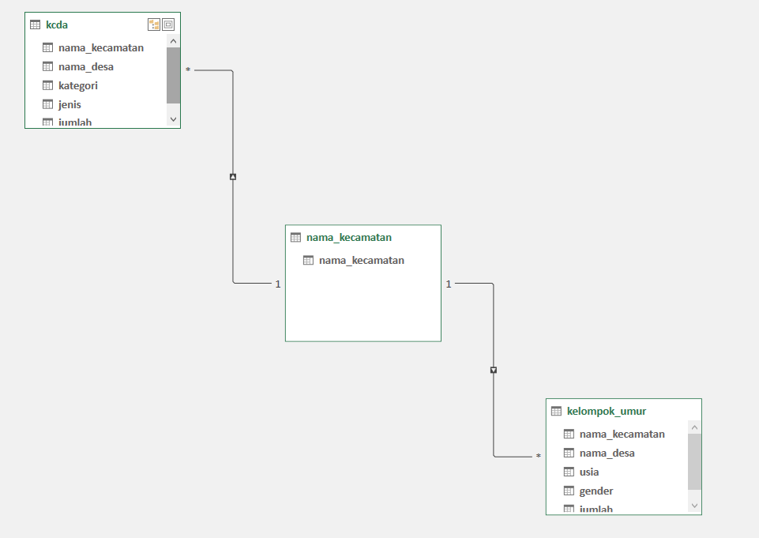

tabel nama_kecamatan akan dijadikan sebagai filter untuk kedua tabel lainnya.

### 3. Mempersiapkan format tabel dan diagram untuk publikasi dengan Pivot Table

1. Tabel KCDA :

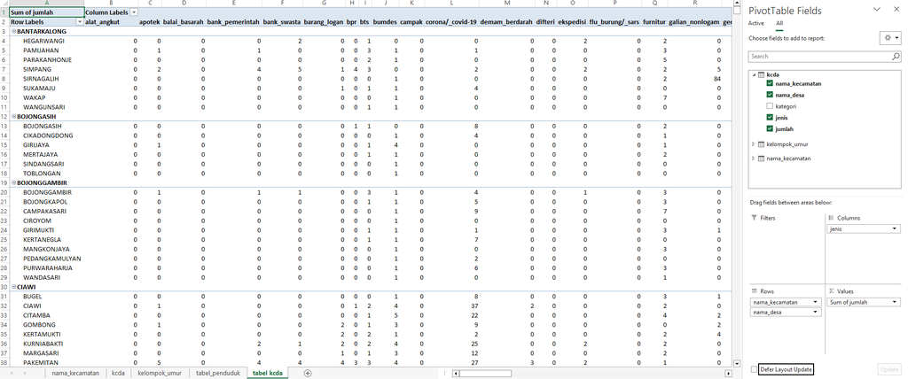

2. Tabel penduduk menurut kelompok umur :

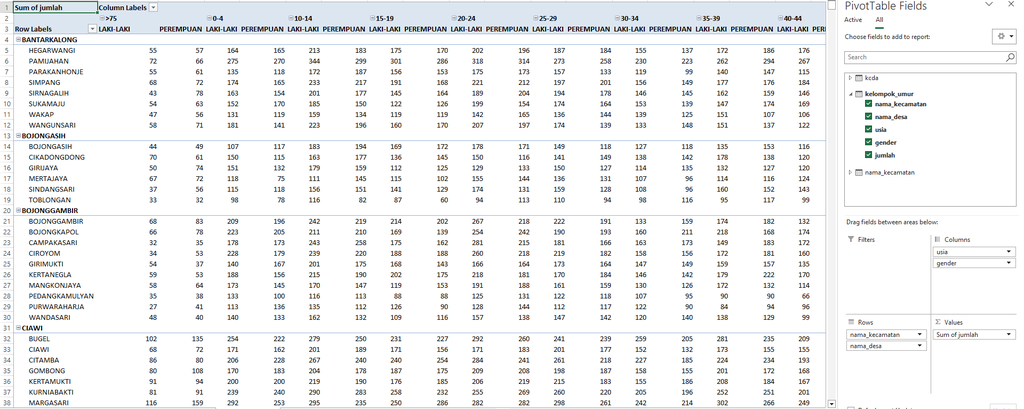

3. Chart :

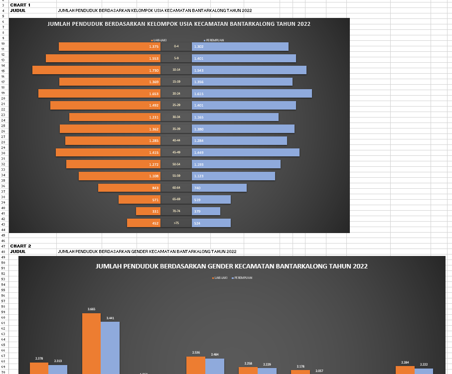

### 4. Membuat slicer untuk filter

Untuk memfilter data berdasarkan kecamatan, saya menggunakan slicer yang diambil dari tabel nama_kecamatan karena sudah terkoneksi ke tabel KCDA dan tabel penduduk.

1. Filter berdasarkan kecamatan :

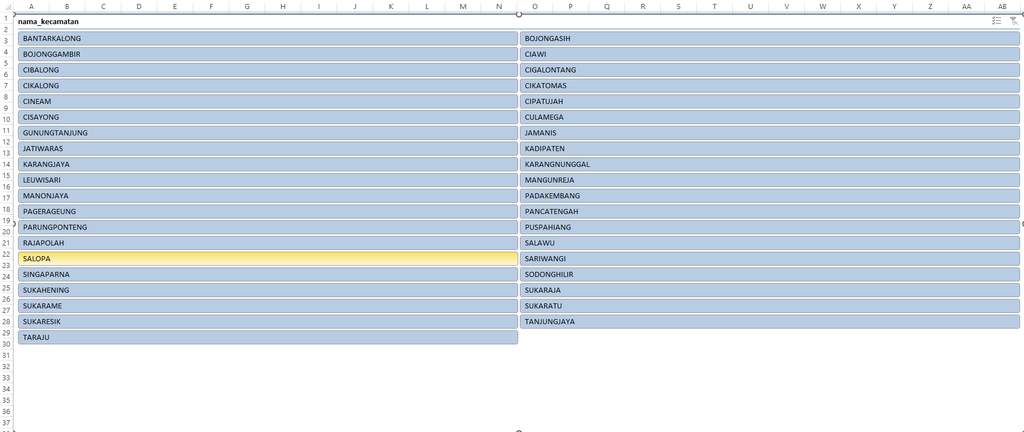

2. Filter kcda berdasarkan kategori :

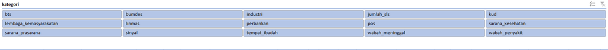

#### 4.1 Mengatur koneksi Slicer

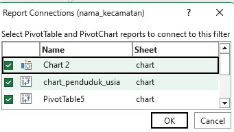

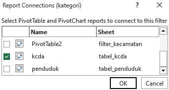

Dengan dibuatnya slicer, maka tabel semua tabel dan diagram akan menampilkan hasil berdasarkan kecamatan tertentu sehingga pengerjaan untuk input data ke dalam template buku publikasi menjadi lebih terorganisir.

# HASIL PUBLIKASI

Pembuatan template buku publikasi ini dibuat dengan Adobe Indesign. Jumlah buku yang dibuat adalah 39 buku yaitu tentang Kecamatan Dalam Angka 2022 dan masing- masing buku berisi 9 bab. Hasil buku ini, di publikaikan di website BPS sendiri dan juga dalam bentuk fisik. Berikut link dibawah ini merupakan hasil dari publikasi kecamatan dalam angka tahun 2022 :

[Hasil](https://tasikmalayakab.bps.go.id/id/publication?keyword=Kecamatan&onlyTitle=true&year=2022&sort=latest)

```python
!jupyter nbconvert --to html kcda_bps2022.ipynb
```

```
[NbConvertApp] Converting notebook kcda_bps2022.ipynb to html
[NbConvertApp] Writing 586420 bytes to kcda_bps2022.html
```